# act_report

## Report: act_report

## WeRateDogs Twitter Data wrangling task

Data analysis has always been a fascinating skill area which allows all data to be gathered from all sources, assessed and cleaned and then explored to produce fascinating analysis and visualizations.

Data that was gathered with a lot of quality and tidiness issues can be transformed into beautiful dashboards, visualizations and meaningful reports for various reports.

### Research Questions

1. What were the most popular breeds predicted by the image prediction model?
2. What was the most popular dog stage in the twitter_archive dataframe?
3. Were the ratings affected by the retweet counts and favorite counts?
4. Which year has the most tweets?
5. How has retweet count changed over the years?

### Insight 1

A scatter plot of year against retweet count

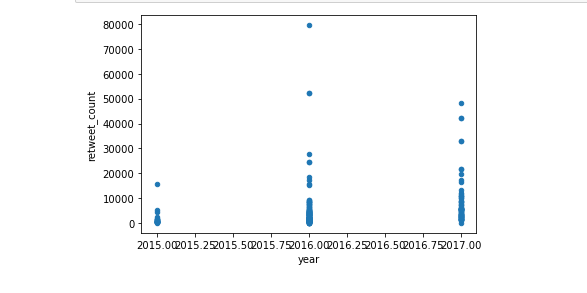

2016 is the year with the highest retweet counts and 2015 had very low retweet counts in comparison.

### Insight 2

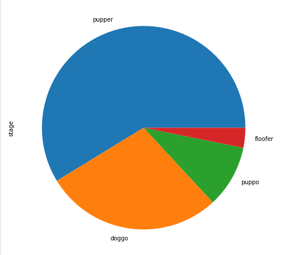

### Insight 3

Although, 12 is the most occuring rating in the master twitter_archive dataframe, 13 is the rating with the highest number of retweet counts and favorite counts.

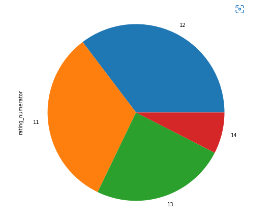

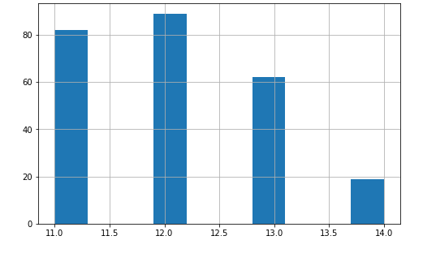

[figure not shown]

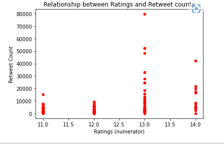

### Insight 4

Most of the dogs (almost in 50:50 ratio) in the dataframe do not have names. We do see that the names Bo, Sampson, Oliver and Loki are the most popular names in comparison to the others.

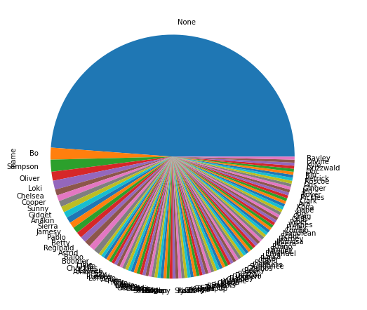

### Insight 5

The top two most popular breeds predicted by the image prediction model are Labrador retriever and the Golden retriever.

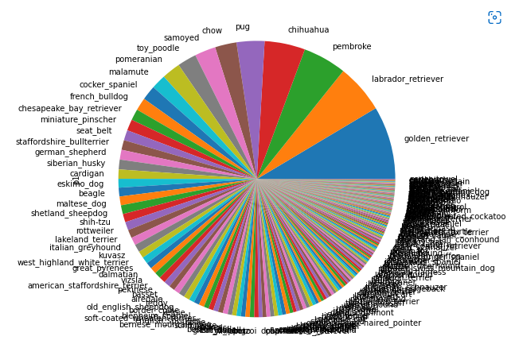

### Limitations

1.The data had a lot of zero values and null values

2.redundant data and timestamping issues

3.rating above 10 are unrealistic

### Reference

1. https://stackoverflow.com/questions/22649693/drop-rows-with-all-zeros-in-pandasdata-frame
2. https://classroom.udacity.com
3. https://pandas.pydata.org/pandas-docs/stable/reference/api/pandas.melt.html